# Flights On Time

## by Vincent Khor

## Investigation Overview

The goal of this investigation is to examine flight performance data to see whether certain variables are present that could affect whether a flight's on-time performance. I will be focusing mainly on the variables that affect whether a flight is more likely to be cancelled or delayed.

## Dataset Overview

This dataset comes from the Bureau of Transportation Statistics. It contains data about 2,389,217 flights from USA between January - April 2008. On-time performance of domestic flights by large carriers are included. Information includes the number of on-time, delayed, cancelled and diverted flights.

## What are the reasons for flight cancellations?

There are four categories for flight cancellations: carrier, weather, NAS and security. The two most common reasons for flight cancellations are carrier and weather. NAS has approximately half the frequency and security is the rarest reason as only 6 flights were cancelled for this reason.

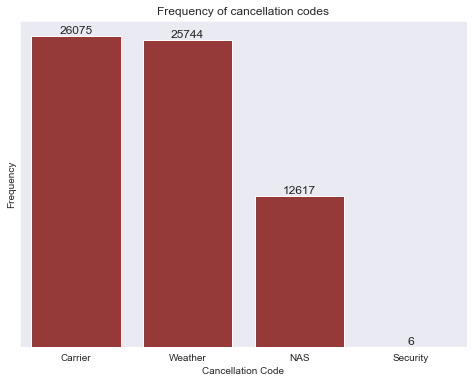

## What proportion of flights are delayed?

A large proportion of flights do not depart on time, 58.4% do depart on time but 41.6% are delayed. Percentages are displayed as it allows for easier comparison.

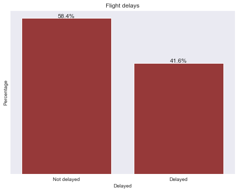

## What is the proportion of delays by carrier?

The proportion of delays by carrier varies greatly. Two of the carriers, WN and CO have over 50% of flights delayed whilst the two best carriers are AQ and HA who both have less than 20% of flights delayed.

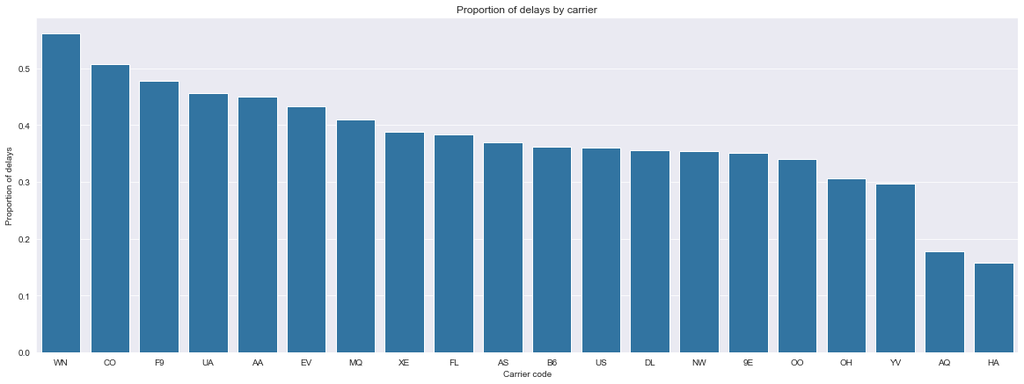

## What is the distribution of flight delays?

The majority of flights depart and arrive on time, in fact, most flights actually arrive early. This suggests that a lot of flights are able to makeup time during the flight to reduce the delay or even arrive early.

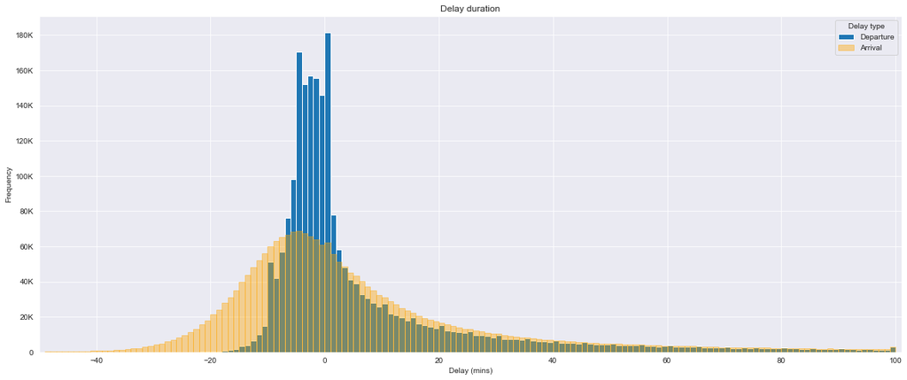

## What was the major cause of delay and does this trend differ depending on the day of the week?

When examining the major causes of delay, it is clear that weather causes the greatest average increase in delay time, weather delays increase delays by on average 70mins. Late aircraft was next closely followed by carrier delays, both of these had average delays of 50-60mins. The two least impactful delays were NAS followed by security, these only had delays of 30-40mins on average. The trend for all of these remains consistent when categorised by day of the week.

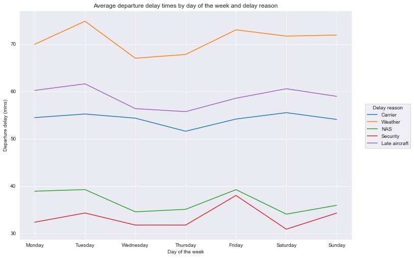

## Summary

- The main reason for cancellations are carrier and weather.
- 58.4% of flights do depart on time but 41.6% are delayed.
- Carriers WN and CO have the highest proportion of delays whilst AQ and HA have the lowest.
- Most flights depart on time but most flights arrive early, this suggests that flights can makeup time during the flight.
- Weather delays create the longest delays followed by late aircraft and carrier. The least impactful delays are NAS and security.